# Unit 4 Loading Data 作業總評

2021/10/28

## 作業評分總原則

從這次的總評表開始，第一部分是總原則說明，讓同學了解教練與助教評分的方式。單元3在幾乎空白的Rmd檔案演練，引導同學認識Rmarkdown的構成。Rmarkdown的編輯指引可參考[速查表](https://rstat-project.github.io/Reproducible_STAT/cheatsheets/rmarkdown-2.0-TC.pdf)，提供需要指引的同學隨時參考。

### 準時推送(OT)

單元2起每次作業繳交期限是TA office hour結束後一小時，單元3因為遇到連假，截止日期時間延後到2021/10/12 14:00:00。根據Assignment.html更新的日期時間決定，教練有寫R code，用來檢測各位同學的作業repo裡有沒有Assignment.html？Assignment.html的日期時間有沒有超過繳交期限？如果有作業網頁且未逾時，OT評分就是“非常厲害”；如果過了繳交期限，從這個單元開始，OT評分就是“需要加把勁”，過了下一次上課開始時間，就沒有評分了。

### 演練充分度(OC)

為激勵同學使用Rmarkdown演練程式碼寫作及紀錄一般筆記，單元2開始會要求同學務必上傳有完整開頭的Assignment.html。單元3上課一開始就有說明，了解如何製作有完整開頭的Assignment.html。另一方面，繳交的作業缺少Assignment.html，就沒有OC評分了。

因為大部分演練項目都會是在上課時完成，如果Assignment.html並沒有呈現這些項目的演練成果，但是有嘗試做課後演練項目，代表你上課時可能沒有跟上示範，課後並沒有嘗試加強學習，你的作業OC評分會是“需要加把勁”。

**請注意！**如果上課 時未完成演練項目，課後也一定要補上。如果只做課後演練項目，評分也是“需要加把勁”。

每個單元會有幾個項目是主要演練項目，主要演練項目的回答是用來評估你的OC評分是“還算可以”、“相當不錯”、還是“非常厲害”。如果每個演練項目你都有提出回答，但是主要演練項目的回答不夠完整，OC評分會你的整份作業答題狀況，得到“還算可以”或“相當不錯”，差異在於教練和助教都覺得你的主要演練項目可以改進的比例超過一半，就會是“還算可以”。如果所有演練項目都有做，主要演練項目有達到教練認可的標準，OC評分就是“非常厲害”。

### 演練活用度(EO)

EO評分以點數計算，計算方式目前有以下幾種：

- 回覆討論區的單元討論貼文

以下是出現在討論區，每個單元討論貼文的固定置頂內容。

```
歡迎分享你學習這個單元時發現的問題 (😄)
還有你認為有助學習這個單元的任何資訊或技巧 (🎉)
留意上課會出現意外的限量搶答(👍)

教練給予以上任何一種表情符號，均列入演練活用度評分。
```

由於表情符號是unicode字符的一種，教練能直接運用網頁搜尋計算次數，獲得任何一種表情符號，計一次EO點數。

作業演練項目有標記**活用**的項目，請將成果回覆到單元討論區帖子，方便教練和助教清點。

- 分享運用心得

在討論區以“💡Ideas”張貼心得文，說明使用那些單元的技巧或觀念解決問題。

- 分享學習問題

在討論區以“🙏Q&A”張貼問題，說明你遇到的技巧或觀念問題。回覆者的回答有助解決問題，可獲得🎉 。

不論是那種狀況，一個單元每位同學可獲得的EO點數上限是4點。複數單元的心得或學習問題，請自行指定要計入那個單元作業評分。

## 單元4學習重點與建議

單元4是R程式設計及描述統計第一部分的第一課，這個部份包括單元4到單元8，如果單元4的學習不夠紮實，會影響這個部分的學習，即使錯過可補繳作業的時限，同學必須徹底演練每個項目，才能透徹整頓資料及描述計基本功。

這次的主要演練項目是“練習3”與“練習7”。“練習3”是匯入演練資料，除了後續單元6,7,8都會是由此演練項目開始，也是要同學養成資料與分析程式碼分開存放的習慣。這樣習慣的好處很多，最大的好處是能確保任何程式碼的更動造成的錯誤，不會影響到資料。只要`dat`與`pinfo`都是由預存的路徑匯入，OC評分至少可獲得“還算可以”。

“練習7”引導同學運用技巧自學了解R函式的功能，透過逐行檢視，在統計圖之下簡述每個函式的效果，加上練習3符合標準，評分就能達到“相當不錯”。這項練習更重要的目的是要同學了解運用這樣的技巧，能從各路範例程式碼學得需要的功能。

如果你的OC評分要到“非常厲害”，除了練習3與練習7，所有項目你都要紀錄[講義](https://rstat-project.github.io/ug-tactic/%E9%80%B1-04_%E5%88%9D%E7%AA%BA%E7%A0%94%E7%A9%B6%E8%B3%87%E6%96%99.html)中提示的學習重點。你缺了那一項，教練或助教會在個人回饋單裡提示。

## 作業繳交狀況

繳交期限到第5單元上課之前，各日繳交人次統計如下圖：

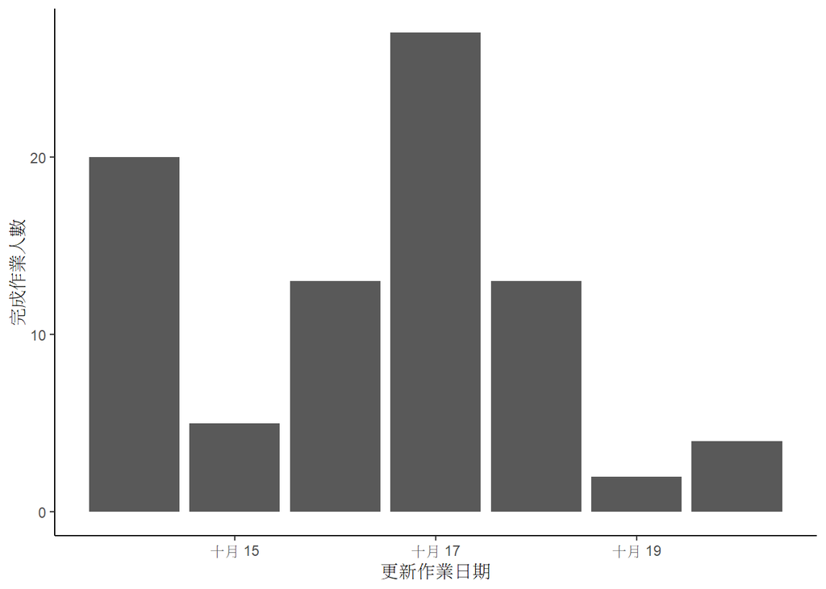

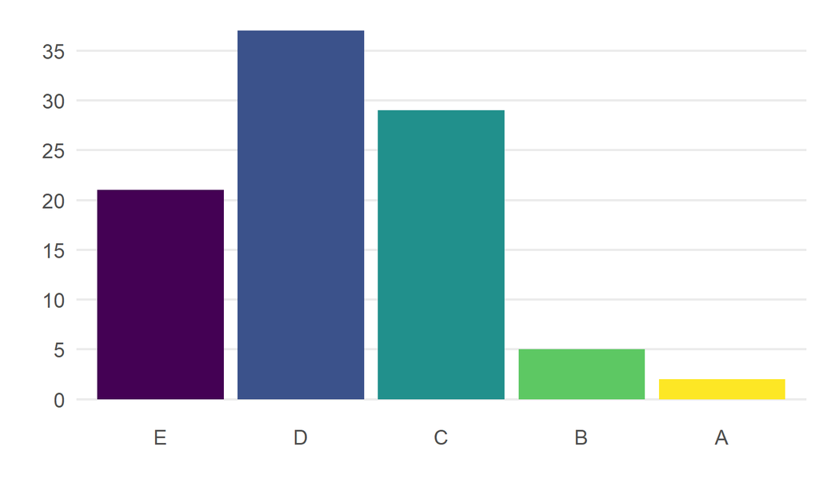

## 檢視個人回饋單

有收到個人評語的同學，只要以瀏覽器開啟feedback.html，就能看到教練和組教給的評語。